# GitHub 101

Ishaan Dey

Fall 2020

Welcome to our crash course on GitHub!

# The Big Picture

## Git

Let’s say we want to start a new project, looking at some star wars data. We start out with an empty project folder `star-wars/`, and add `characters.csv`, `planets.csv`, & `viz.ipynb`. Currently, our local directory (our laptop’s folder) looks like this:

```
└── star-wars
    ├── datasets
    │   ├── characters.csv
    │   └── planets.csv
    └── viz.ipynb
```

As we’re cleaning the datasets, we accidentally write over some data in `planets.csv`, and the correct data is permanently lost. Luckily, we’ve been using a Git repository, so we just rollback to a previous version, and continue coding.

**Git** is a version control system. Much in the way Microsoft Word or Google Docs allow us to look back at previous versions of a document, Git gives us the ability to track changes to a project.

Git does this by taking a **series of snapshots** of the project over time. Everytime we save the state of the project, or **commit**, Git takes a picture of what all the files looked like just in that moment of time. It stores this information in a “database” of sorts.

When we take a look at these changes, we can view a quick summary of what changed. For example with `planets.csv`:

```
name, climate, terrain, population
Alderaan, temperate, grasslands, 2 billion
Hoth, frozen, tundra, NA
Endor, temperate, forests, 30 million
- Naboo, temperate, grassy hills, 4.5 billion
+ Naboo, temperate, forests, 4.2 billion
```

Each one of these snapshots are saved in sequence, so Git allows us to see *versions over time*, then *go back to previous ones* with ease.

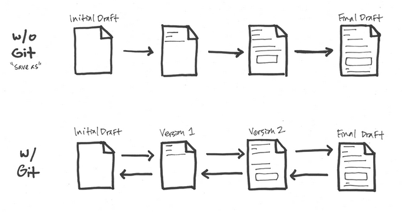

Versioning

In fact, every time a file in our project changes at all, git recognizes and remembers the change. That information gets stored into a hidden git “database”, also known as a **git repository**.

```
└── star-wars
    ├── .git
    │   └── ...
    ├── datasets
    │   ├── characters.csv
    │   └── planets.csv
    └── viz.ipynb
```

## GitHub

Let’s say we’d like to share our project with a friend, who wants to build a machine learning model from our data.

**GitHub** makes collaboration super easy. To be clear, *GitHub* is entirely seperate from *git*. GitHub is an *online platform* that hosts repositories, using the git version control system.

Getting our existing code online is increadibly easy. Since we’ve already initialized the repository locally, we just create a corresponding repo on GitHub, and tell our local repo to connect to that particular remote repo.

All our friend has to do is **clone**, or download a copy of the remote repo to her laptop.

Whenever she’s made edits that she’d like to share, she can **push** those commits from (her) local to the remote repo. To bring her changes into my local repo, I can **pull** her commits down.

[figure not shown]

Source: Git-It

That’s it! There’s a lot more to Git, including Branching and Pull Requests, but this is enough to get us started.

# Basics of Bash

Back in the day, like wayyy back in the day, computers were nothing more than simple command line interfaces, a big black screen with a blinking cursor. Instead of dragging and dropping files, you’d need to explicitly type out the file to move, from where to where.

These operating systems were typically on Unix, a family of similar operating systems developed originally in the 1970s. To interact with those operating sytems, users would write their commands in a “shell”, named as such because it was the “outermost layer around the operating system”. The first such shell to be used with Unix was the “Bourne Shell”, or just `sh`. Plenty more exist nowadays, but by far the most common is `bash`, or the “Bourne Again Shell”.

On modern machines, MacOS and Linux systems are derived from Unix, while Windows systems are not. As such, we can use the `terminal` application on Mac to access a bash shell, and the `ubuntu` terminal on Windows (you’ll have to install this seperately).

## Activities

Download the [zip file](https://files.node.ishaandey.com/week-5/workshop/bash-tutorial.zip) for today’s activity.

There are 5 practice problems. Open them up using your file navigator and favorite text editor, and follow the instructions. Make sure to look out for relative links and file names!

## A quick reference of commands

#### Navigating Files & Directories

- `ls` lists content of a directory. We can add flags, like `ls -l` or `ls -la` to list all files, and all hidden files, respectively
- `cd` changes the directory to a subfolder. If we want to move *up* a level, we can use `cd ..`
- `pwd` present working directory. By default. our working dir is the “root” directory, usually `/Users/ishaandey/`
- `rm` removes the file we specify
- `mv` moves the file we specify. It can also be used for *renaming* files, if we place it back in the same directory.
- `cat` renders the content of a file as text

#### General things to know

- `*` wild cards: Matches anything
- `~` root direcory: The base directory for the OS
- `-flag` flags: Shorthand to modify a command
- `--option` options: Options to modify a command
- `>` the pipe operator: Send output to somewhere
- `^C` clear: Exit out of where you are
- `" "` quotes: Makes sure that the shell interprets a string as text, helpful when there’s a space in the directory name or smth

# The Basic Workflow

We’ve already covered most, if not all of the basics of working with Git. Let’s walk through an example:

At any point, use `git --help` or `git <command> --help` to pull up help pages (Type `q` if you see a `:` in the command line to exit the help pages).

## Set Up Remote

1. Let’s start by **navigating** to a directory of your choice:
   - Open the bash shell of your choice (For MacOS: use `Terminal` — For Windows: use `Git Bash`)
   - Using bash commands, `cd` into your directory (use `mkdir` to make a directory if needed)
   - Make sure there’s at least one file in this directory
2. **Initialize** the repository with `git init`:
   - This creates a hidden `.git` directory, which we can now reveal with `ls -la`
3. **Stage** all changes using `git add --all`. Whenever Git detects a change to a file, it goes into one of 3 distinct phases:
   - **Modified** means that the file is changed, but isn’t yet *saved to the repo*. This occurs by default. These changes as saved in the *working directory*.
   - **Staged** means we’ve *marked the modified file* *as ready* to enter into the next commit. We would say that these edits are saved to the *index*.
   - **Committed** means that the snapshot, containing only the staged edits, is now saved to the repo.

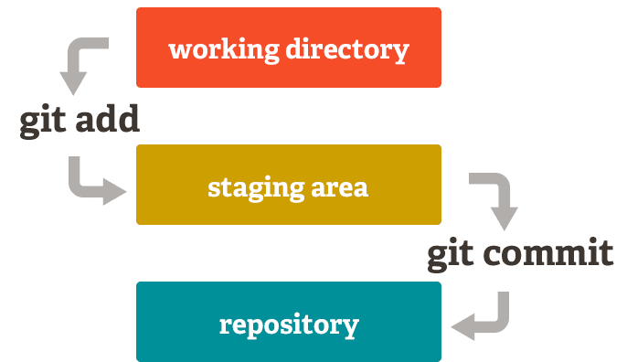

4. **Commit** these changes to the *local* repo using `git commit -m "Initial Commit"`
   - Good practice for naming commits are short statements with a verb up front, i.e. “Add thing x”
5. In order to push our changes up to a remote repository, we first need to **create a GitHub repo**
   - Open up `GitHub Desktop`. On the top left, hit `Add` > `Add existing repository`
   - Hit `choose`, then navigate to the directory where you’ve been working
   - Click `Publish repository`, add a description and make the repo public if you’d like, then publish. Make it private for now
6. Now that we have a `remote` repo set up, we can confirm its location using `git remote -v`
   - This should now point to a link, something like https://github.com/ishaandey/git-crash-courses.git
7. **Push** the commits to remote using `git push`

## Add Changes

1. Head over to your online GitHub repository (github.com/username/reponame)
   - Make sure you’re signed in properly
2. Create a new file online by clicking the `new file` button: call it `hello.txt`
   - GitHub will ask you to save your changes with a commit (it automatically staged them)
   - Because this is already the remote repo, there’s no need to push/pull: the changes are directly commited to remote
3. However, our local directory doesn’t have those changes just yet. We need to **pull** those commits down to local.
   - We could either: (a) go to GitHub Desktop, and click the `fetch & pull` icon
   - Or (b) from the command line, type `git pull`
4. With a text editor, add a few lines to `hello.txt`. Be sure to hit save!
   - Git now knows a file has been changed, but hasn’t yet saved that snapshot to the local repo
5. **Stage** these changes using `git add hello.txt`
   - If we modified multiple files, all of which we’d like to stage, we could simply use `git add .`
6. **Commit** these changes, using `git commit -m "Added some lines"`
   - The `-m` flag allows us to attach a message to the commit- This is super helpful for annotating edits
7. Finally, **push** these changes to the remote repository using `git push`.
   - If all is well, you should now be able to see those new lines online!

You’re done! This is the basic workflow of Git. We modify files, stage then commit them. We push changes to remote, and pull changes to local.

**Draw a quick diagram of this workflow**, just to make sure you understand the basic idea here. Draw your laptop (local), the GitHub server (remote), the commands to interact between the two, as well as the commands to save changes locally.

# Branching

```
.          __---__
    .   .-'...:...'-.               .          .
       / .  . : .__ .\                                         .
.     /........./  \ .\  .   .               git checkout         .
     / :  :   :| () | :\                  .        .
    :...........\__/....:         .                             .
    |___________________|              .        |    |  .                .
    |...................|               .       |    |
    :  :  :   :   :   : :                       |=()=|          .
  .  \................./      .            .    |    |
      \  .  . : .  .  /                         |  . |           .
   .   \._........._./  .        .                   .
          -..___..-                .         .             .                .
                      .                                               .
    .    origin/master                   .               .
                                 .              .                         .
```

At a high-level, branching is a key feature that allows us to keep production-ready, stable code seperate from the development code, where we’re likely to experiment and break things as we go along.

Think of **branches** as *copies* of our repository. The core, stable, copy of the code is called the `master` branch. This is considered the default branch.

Let’s say we want to improve our machine learning models, BUT we don’t want to overwrite the previous code, in case our new models fail. To do this, we’ll branch off of master, creating a new branch called `improve-ml`. We can play around as much as we need there, and once we’re done, we can merge these changes back into `master`.

### Workflow

There are tons of workflows that describe this process. The one I’ve been using for the node repository uses `master`/`develop`/`feature` branches, based on the model [described here](https://nvie.com/posts/a-successful-git-branching-model/).

# TLDR

## Definitions

- *Git* is a version control system, *GitHub* is an online platform
- *Commits* store “snapshots” of what our project looks like in a particular point in time
- A *repository* is how we save these commits using the Git system
- *Branch*es can be thought of as a “copy” (of sorts), of the main repository. This allows us to test out various features without breaking existing code.
- *Remote* is the version of our repository that lives online at GitHub

## Workflow

- Whenever we want to store a change, we *modify*, *stage*, and *commit*
- To *get* the most recent changes, we *pull* them down
- To *upload* our most recent changes, we *push* them up
- To test out features, we use *branches*

## Acknowledgements & Resources

- [Git SCM](https://git-scm.com/book/en/v2/Getting-Started-What-is-Git%3F)
- [Git Branching Model](https://nvie.com/posts/a-successful-git-branching-model/)
- [Interactive Git Practice](https://github.com/jlord/git-it-electron)